```r
#create proportion tables
total_table <- bind_rows(table_nonpart, table_part)
table_proportions <- total_table %>%
  group_by(Strata, Retained, Participated) %>%
  dplyr::summarise(total = n()) %>%
  spread(key = Retained, value = total) %>%
  mutate(totals = `0` + `1`) %>%
  mutate(liklihood_not_retained = `0` / totals) %>%
  mutate(liklihood_retained = `1` / totals)

##make this proportion table
#recode the factors
total_table$strata <- as.factor(total_table$Strata)
#levels(total_table$strata)
total_table$strata <- recode_factor(total_table$Strata, `1` = "less than 5", `2` = "5 to less than 10 years", `3` = "10 to 15 years", `4` = "greater than or equal to 15")
table_proportions <- total_table %>%
  group_by(Strata, Retained, Participated) %>%
  dplyr::summarise(total = n()) %>%
  spread(key = Retained, value = total) %>%
  mutate(totals = `0` + `1`) %>%
  mutate(`Likelihood of leaving profession` = `0` / totals) %>%
  mutate(`Likelihood of retention` = `1` / totals) %>%
  arrange(Strata)
library(scales)
table_proportions$`Likelihood of leaving profession` <- percent(table_proportions$`Likelihood of leaving profession`)
table_proportions$`Likelihood of retention` <- percent(table_proportions$`Likelihood of retention`)
table_proportions$totals <- NULL
# #print kable table
# kable(table_proportions, "latex", booktabs = T, caption = "Liklihood of Retention") %>%
#   kable_styling(latex_options = c("repeat_header", "striped", "scale_down"), font_size = 12, repeat_header_text = "TABLE") %>%
#   column_spec(5:6, width = "4cm")
```

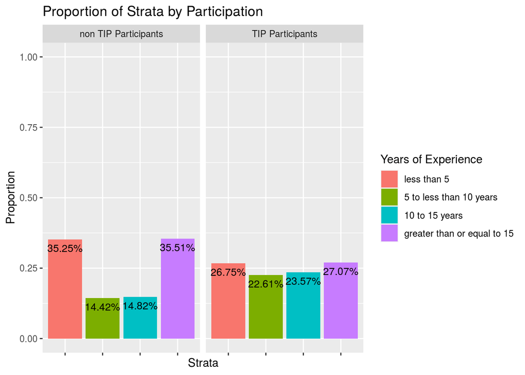

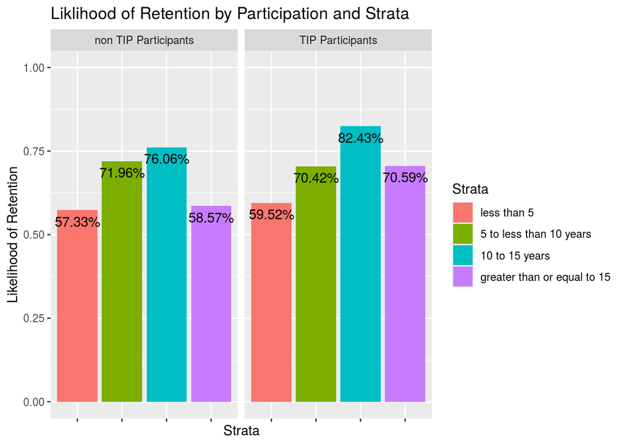

In order to continue with a statistical analysis, we create an analysis dataset with a row for each Deidentified ID that has all of its unique variables. Recall that the merged_dataset has multiple rows for the same Deidentified ID. For instance, teacher ID #72 may have changed schools over the time we have the data. Or, teacher ID #72 may have changed their title (example: a Special Education teacher moving to a General Education teacher). In order to capture that change, we can come up with a new variable that records the number of times the teacher changed schools, titles, etc.

Variables that change for each ID, such as gender, or school, will be gathered and then re-coded. For instance, the original data set had a unique entry for each year in the data. Here, that is recoded as “total years in TIP data set”. Or, some teachers changed gender over the time frame. This is recoded as “number of genders”. Or, some teachers changed schools during the time frame. This is recoded as “number of schools”.